# Sleep, Stress, and Mental Health Patterns

Areen Khalaila

Website: https://areenkh.github.io/mental-health/

## Tutorial Roadmap

This notebook follows the full data science lifecycle required for the final tutorial:

1. Introduction and motivation
2. Data extraction, transform and load (ETL)
3. Exploratory data analysis (EDA)
4. Model building and testing
5. Conclusions and recommendations

## Main Questions

- How strongly are sleep quality, sleep duration, and physical activity related to stress?
- Do people who report growing stress also report greater difficulty coping?
- How do anxiety and depression patterns vary across student groups?
- Can lifestyle variables be used to predict whether someone belongs to a higher-stress group?

These questions allow the project to explore mental health from multiple perspectives using different but related datasets.

## Datasets Used

Dataset 1: https://www.kaggle.com/datasets/uom190346a/sleep-health-and-lifestyle-dataset

Dataset 2: https://www.kaggle.com/datasets/bhavikjikadara/mental-health-dataset

Dataset 3: https://www.kaggle.com/datasets/shariful07/student-mental-health

## 1. Introduction and Motivation

Mental health is influenced by many factors, including sleep habits, physical activity, academic pressure, and perceived stress. This makes mental health a strong topic for data science because it combines behavioral data, survey responses, and predictive modeling.

Rather than relying on a single dataset, this tutorial uses **three related datasets** to study the topic from complementary angles. The first dataset captures lifestyle and sleep behavior, the second focuses on stress and coping, and the third examines mental health outcomes in a student population. Together, they help build a broader story: stress is not just an isolated number, but part of a larger behavioral and social pattern.

The final modeling section focuses on the **Sleep Health and Lifestyle** data because it contains structured numeric and categorical features that are well suited for machine learning. The other two datasets strengthen the tutorial by providing additional context about coping and student well-being, which helps motivate why stress prediction is meaningful in the first place.

## 2. Data Extraction, Transform and Load (ETL)

I begin by loading the three datasets, standardizing column names, checking data types, and creating cleaner variables for analysis.

### 2.1 Setup and Imports

```python
#pip install pandas matplotlib seaborn
```

```python
# Check current working directory
import os
os.getcwd()
```

```
'/Users/akhalaila/Desktop'
```

### 2.2 Dataset 1: Sleep Health and Lifestyle

```python
import pandas as pd
import matplotlib.pyplot as plt
import seaborn as sns
# Load dataset
df = pd.read_csv('Sleep_health_and_lifestyle_dataset.csv')

df.head()
```

|  | Person ID | Gender | Age | Occupation | Sleep Duration | Quality of Sleep | Physical Activity Level | Stress Level | BMI Category | Blood Pressure | Heart Rate | Daily Steps | Sleep Disorder |
| --- | --- | --- | --- | --- | --- | --- | --- | --- | --- | --- | --- | --- | --- |
| 0 | 1 | Male | 27 | Software Engineer | 6.1 | 6 | 42 | 6 | Overweight | 126/83 | 77 | 4200 | NaN |
| 1 | 2 | Male | 28 | Doctor | 6.2 | 6 | 60 | 8 | Normal | 125/80 | 75 | 10000 | NaN |
| 2 | 3 | Male | 28 | Doctor | 6.2 | 6 | 60 | 8 | Normal | 125/80 | 75 | 10000 | NaN |
| 3 | 4 | Male | 28 | Sales Representative | 5.9 | 4 | 30 | 8 | Obese | 140/90 | 85 | 3000 | Sleep Apnea |
| 4 | 5 | Male | 28 | Sales Representative | 5.9 | 4 | 30 | 8 | Obese | 140/90 | 85 | 3000 | Sleep Apnea |

```python
df.info()
df.describe()
```

```
<class 'pandas.core.frame.DataFrame'>
RangeIndex: 374 entries, 0 to 373
Data columns (total 13 columns):
 #   Column                   Non-Null Count  Dtype
---  ------                   --------------  -----
 0   Person ID                374 non-null    int64
 1   Gender                   374 non-null    object
 2   Age                      374 non-null    int64
 3   Occupation               374 non-null    object
 4   Sleep Duration           374 non-null    float64
 5   Quality of Sleep         374 non-null    int64
 6   Physical Activity Level  374 non-null    int64
 7   Stress Level             374 non-null    int64
 8   BMI Category             374 non-null    object
 9   Blood Pressure           374 non-null    object
 10  Heart Rate               374 non-null    int64
 11  Daily Steps              374 non-null    int64
 12  Sleep Disorder           155 non-null    object
dtypes: float64(1), int64(7), object(5)
memory usage: 38.1+ KB
```

|  | Person ID | Age | Sleep Duration | Quality of Sleep | Physical Activity Level | Stress Level | Heart Rate | Daily Steps |
| --- | --- | --- | --- | --- | --- | --- | --- | --- |
| count | 374.000000 | 374.000000 | 374.000000 | 374.000000 | 374.000000 | 374.000000 | 374.000000 | 374.000000 |
| mean | 187.500000 | 42.184492 | 7.132086 | 7.312834 | 59.171123 | 5.385027 | 70.165775 | 6816.844920 |
| std | 108.108742 | 8.673133 | 0.795657 | 1.196956 | 20.830804 | 1.774526 | 4.135676 | 1617.915679 |
| min | 1.000000 | 27.000000 | 5.800000 | 4.000000 | 30.000000 | 3.000000 | 65.000000 | 3000.000000 |
| 25% | 94.250000 | 35.250000 | 6.400000 | 6.000000 | 45.000000 | 4.000000 | 68.000000 | 5600.000000 |
| 50% | 187.500000 | 43.000000 | 7.200000 | 7.000000 | 60.000000 | 5.000000 | 70.000000 | 7000.000000 |
| 75% | 280.750000 | 50.000000 | 7.800000 | 8.000000 | 75.000000 | 7.000000 | 72.000000 | 8000.000000 |
| max | 374.000000 | 59.000000 | 8.500000 | 9.000000 | 90.000000 | 8.000000 | 86.000000 | 10000.000000 |

```python
df.columns
```

```
Index(['Person ID', 'Gender', 'Age', 'Occupation', 'Sleep Duration',
       'Quality of Sleep', 'Physical Activity Level', 'Stress Level',
       'BMI Category', 'Blood Pressure', 'Heart Rate', 'Daily Steps',
       'Sleep Disorder'],
      dtype='object')
```

```python
# Clean column names (lowercase, remove spaces)
df.columns = df.columns.str.strip().str.lower().str.replace(' ', '_')
```

```python
df.columns
```

```
Index(['person_id', 'gender', 'age', 'occupation', 'sleep_duration',
       'quality_of_sleep', 'physical_activity_level', 'stress_level',
       'bmi_category', 'blood_pressure', 'heart_rate', 'daily_steps',
       'sleep_disorder'],
      dtype='object')
```

```python
df[['quality_of_sleep', 'stress_level']].describe()
```

|  | quality_of_sleep | stress_level |
| --- | --- | --- |
| count | 374.000000 | 374.000000 |
| mean | 7.312834 | 5.385027 |
| std | 1.196956 | 1.774526 |
| min | 4.000000 | 3.000000 |
| 25% | 6.000000 | 4.000000 |
| 50% | 7.000000 | 5.000000 |
| 75% | 8.000000 | 7.000000 |
| max | 9.000000 | 8.000000 |

```python
# I want to find the correlation between quality of sleep and the stress level of the participants
# If it’s negative then better sleep = lower stress
# If positive then opposite
df['quality_of_sleep'].corr(df['stress_level'])
```

```
np.float64(-0.8987520310040414)
```

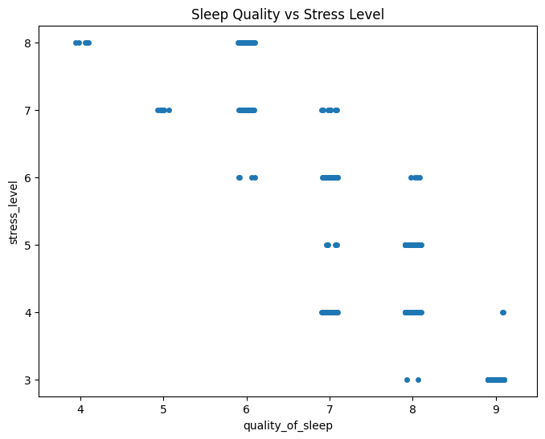

```python
# Plot relationship between sleep quality and stress level
plt.figure(figsize=(8,6))
# sns.scatterplot(data=df, x='quality_of_sleep', y='stress_level')
sns.stripplot(data=df, x='quality_of_sleep', y='stress_level', jitter=True)
plt.title("Sleep Quality vs Stress Level")
plt.show()
```

For the first question, I look directly at the relationship between **quality of sleep** and **stress level**. Because both variables are central to the final tutorial, this early check helps confirm that the dataset is capable of answering a meaningful question.

The scatterplot appears to show relatively few points because both variables are discrete, causing many observations to overlap at the same coordinates. In reality, multiple observations share the same sleep quality and stress level values, resulting in overplotting.

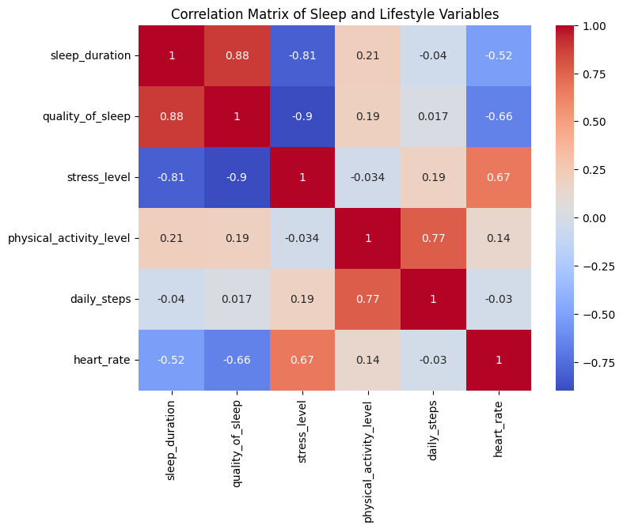

```python
# Compute and visualize correlations between lifestyle and sleep variables
corr_matrix = df[['sleep_duration','quality_of_sleep','stress_level','physical_activity_level','daily_steps','heart_rate']].corr()

plt.figure(figsize=(8,6))
sns.heatmap(corr_matrix, annot=True, cmap="coolwarm")
plt.title("Correlation Matrix of Sleep and Lifestyle Variables")
plt.show()
```

The heatmap shows the correlations between key sleep and lifestyle variables in the dataset. Sleep duration and sleep quality have a strong positive correlation (0.88), indicating that individuals who sleep longer tend to report better sleep quality. Both sleep duration and sleep quality show strong negative correlations with stress level (-0.81 and -0.90), suggesting that better sleep is associated with lower stress. Additionally, physical activity level is strongly correlated with daily steps (0.77), which reflects expected behavioral patterns. These relationships suggest that sleep and lifestyle behaviors are closely linked to stress levels.

### Dataset 2: Mental Health Dataset

This dataset contains survey responses related to stress experiences, coping behaviors, and mental health indicators. Variables include measures such as growing stress, coping struggles, mood swings, family history of mental health conditions, and lifestyle-related behavioral changes.

This dataset is valuable because it allows for examination of how perceived stress relates to behavioral and psychological responses. Rather than focusing on treatment-seeking behavior, this analysis explores whether individuals reporting increased stress also report greater difficulty coping.

```python
# Load dataset
mh = pd.read_csv('Mental Health Dataset.csv')

mh.head()
```

|  | Timestamp | Gender | Country | Occupation | self_employed | family_history | treatment | Days_Indoors | Growing_Stress | Changes_Habits | Mental_Health_History | Mood_Swings | Coping_Struggles | Work_Interest | Social_Weakness | mental_health_interview | care_options |
| --- | --- | --- | --- | --- | --- | --- | --- | --- | --- | --- | --- | --- | --- | --- | --- | --- | --- |
| 0 | 8/27/2014 11:29 | Female | United States | Corporate | NaN | No | Yes | 1-14 days | Yes | No | Yes | Medium | No | No | Yes | No | Not sure |
| 1 | 8/27/2014 11:31 | Female | United States | Corporate | NaN | Yes | Yes | 1-14 days | Yes | No | Yes | Medium | No | No | Yes | No | No |
| 2 | 8/27/2014 11:32 | Female | United States | Corporate | NaN | Yes | Yes | 1-14 days | Yes | No | Yes | Medium | No | No | Yes | No | Yes |
| 3 | 8/27/2014 11:37 | Female | United States | Corporate | No | Yes | Yes | 1-14 days | Yes | No | Yes | Medium | No | No | Yes | Maybe | Yes |
| 4 | 8/27/2014 11:43 | Female | United States | Corporate | No | Yes | Yes | 1-14 days | Yes | No | Yes | Medium | No | No | Yes | No | Yes |

```python
# Clean column names (lowercase, remove spaces)
mh.columns = mh.columns.str.strip().str.lower().str.replace(' ', '_')
```

```python
mh.columns
```

```
Index(['timestamp', 'gender', 'country', 'occupation', 'self_employed',
       'family_history', 'treatment', 'days_indoors', 'growing_stress',
       'changes_habits', 'mental_health_history', 'mood_swings',
       'coping_struggles', 'work_interest', 'social_weakness',
       'mental_health_interview', 'care_options'],
      dtype='object')
```

```python
mh['growing_stress'] = mh['growing_stress'].astype(str).str.strip().str.lower()
mh['coping_struggles'] = mh['coping_struggles'].astype(str).str.strip().str.lower()
```

```python
# Convert responses to numeric values
mh['coping_num'] = mh['coping_struggles'].map({'yes': 1, 'no': 0})
```

```python
# Calculate coping struggle percentage by stress level
coping_rate = (mh.dropna(subset=['coping_num']).groupby('growing_stress')['coping_num'].mean() * 100)

coping_rate
```

```
growing_stress
maybe    44.751713
no       49.733624
yes      47.339267
Name: coping_num, dtype: float64
```

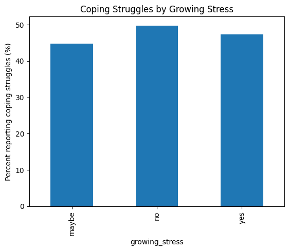

```python
# Visualize coping struggle rates by reported stress level
coping_rate.plot(kind='bar')
plt.ylabel('Percent reporting coping struggles (%)')
plt.title('Coping Struggles by Growing Stress')
plt.show()
```

### Dataset 3: Student Mental Health Dataset

This dataset is particularly useful for examining how mental health indicators vary across academic disciplines and whether certain fields of study are associated with higher levels of anxiety or stress.

In this dataset, the main ETL work is converting survey answers such as `"yes"` and `"no"` into numeric values so that percentages can be computed cleanly.

This step is important because it tests whether perceived stress is meaningfully connected to other mental health challenges. If it is, that strengthens the case for treating stress as a serious and model-worthy outcome.

```python
# Load dataset
smh = pd.read_csv('Student Mental health.csv')
```

```python
# Clean column names (lowercase, remove spaces)
smh.columns = smh.columns.str.strip().str.lower().str.replace(' ', '_')
```

```python
smh.columns
```

```
Index(['timestamp', 'choose_your_gender', 'age', 'what_is_your_course?',
       'your_current_year_of_study', 'what_is_your_cgpa?', 'marital_status',
       'do_you_have_depression?', 'do_you_have_anxiety?',
       'do_you_have_panic_attack?',
       'did_you_seek_any_specialist_for_a_treatment?'],
      dtype='object')
```

```python
# Clean course column
smh['what_is_your_course?'] = smh['what_is_your_course?'].astype(str).str.strip()

# Clean anxiety column
smh['do_you_have_anxiety?'] = (smh['do_you_have_anxiety?'].astype(str).str.strip().str.lower())

smh['do_you_have_anxiety?'].unique()
```

```
array(['no', 'yes'], dtype=object)
```

```python
# Convert responses to numeric values
smh['anxiety_num'] = smh['do_you_have_anxiety?'].map({'yes': 1, 'no': 0})
```

```python
# Compute anxiety prevalence by course
anxiety_by_course = (smh.dropna(subset=['anxiety_num']).groupby('what_is_your_course?')['anxiety_num'].mean().sort_values(ascending=False) * 100)

anxiety_by_course
```

```
what_is_your_course?
psychology                 100.000000
Communication              100.000000
Kop                        100.000000
KENMS                      100.000000
Islamic education          100.000000
Law                        100.000000
Irkhs                      100.000000
Marine science             100.000000
Econs                      100.000000
Koe                        100.000000
ENM                        100.000000
koe                        100.000000
BIT                         80.000000
KOE                         50.000000
BENL                        50.000000
BCS                         33.333333
Engineering                 23.529412
MHSC                         0.000000
engin                        0.000000
Laws                         0.000000
Psychology                   0.000000
Pendidikan islam             0.000000
Usuluddin                    0.000000
Mathemathics                 0.000000
Nursing                      0.000000
TAASL                        0.000000
Radiography                  0.000000
Pendidikan Islam             0.000000
Malcom                       0.000000
ALA                          0.000000
Kirkhs                       0.000000
KIRKHS                       0.000000
Banking Studies              0.000000
Benl                         0.000000
Biomedical science           0.000000
Biotechnology                0.000000
Business Administration      0.000000
CTS                          0.000000
DIPLOMA TESL                 0.000000
Diploma Nursing              0.000000
Engine                       0.000000
Fiqh                         0.000000
Fiqh fatwa                   0.000000
Human Resources              0.000000
Human Sciences               0.000000
IT                           0.000000
Accounting                   0.000000
Islamic Education            0.000000
Name: anxiety_num, dtype: float64
```

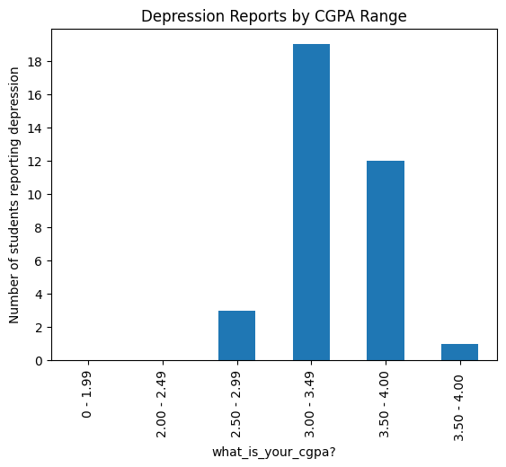

```python
# calculate and plot the number of students reporting depression for each CGPA range
smh['depression_num'] = smh['do_you_have_depression?'].map({'Yes': 1, 'No': 0})
depression_counts = (smh.groupby('what_is_your_cgpa?')['depression_num'].sum())

depression_counts.plot(kind='bar')

plt.ylabel("Number of students reporting depression")
plt.title("Depression Reports by CGPA Range")
from matplotlib.ticker import MaxNLocator
plt.gca().yaxis.set_major_locator(MaxNLocator(integer=True))
plt.show()
```

```python
len(smh)
```

```
101
```

This bar chart shows the number of students within each CGPA range who reported experiencing depression. The visualization helps explore whether depression reports vary across different levels of academic performance.

Because this dataset captures mental health outcomes in an academic context, it complements the first two datasets well. It helps move the tutorial from a general lifestyle perspective toward a population where stress and anxiety are especially relevant.

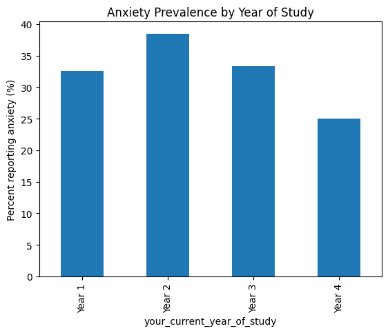

```python
# Clean year labels and visualize anxiety prevalence by year of study
smh['your_current_year_of_study'] = smh['your_current_year_of_study'].str.strip()
smh['your_current_year_of_study'] = smh['your_current_year_of_study'].replace({
    'year 1':'Year 1',
    'year 2':'Year 2',
    'year 3':'Year 3',
    'year 4':'Year 4'
})


anxiety_by_year = smh.groupby('your_current_year_of_study')['anxiety_num'].mean()*100

anxiety_by_year.plot(kind='bar')
plt.title("Anxiety Prevalence by Year of Study")
plt.ylabel("Percent reporting anxiety (%)")
plt.show()
```

This result also illustrates why multiple datasets help: the first dataset shows how lifestyle relates to stress, while this dataset shows how stress and anxiety may cluster in a specific social environment.

## 3. Exploratory Data Analysis

These results are useful descriptively, but they also motivate a predictive step. The next section asks whether those lifestyle variables can be used to predict whether someone belongs to a higher-stress group.

## 4. Model Building and Testing

### 4.1 Modeling Question

For the final tutorial, I focus on the following question:

> **Can lifestyle and sleep variables be used to predict whether a person belongs to a higher-stress group?**

I use the **Sleep Health and Lifestyle** dataset for this model because it contains the cleanest set of predictors for this question. Instead of predicting the exact numeric stress level, I convert stress into a binary outcome called `high_stress`. This makes the task a classification problem, which is easier to interpret and evaluate with metrics such as accuracy, precision, recall, ROC AUC, and a confusion matrix.

### 4.2 Modeling Choice

I use a **Random Forest Classifier** because:

- it can model nonlinear relationships,
- it handles mixed numeric and categorical predictors well after preprocessing,
- it provides feature importance scores,
- it is a strong baseline model for tabular behavioral data.

I also use one-hot encoding for categorical variables and preserve numeric variables directly.

```python
from sklearn.model_selection import train_test_split, cross_val_score
from sklearn.compose import ColumnTransformer
from sklearn.pipeline import Pipeline
from sklearn.preprocessing import OneHotEncoder
from sklearn.metrics import classification_report, confusion_matrix, ConfusionMatrixDisplay, roc_auc_score
from sklearn.ensemble import RandomForestClassifier
import numpy as np

# Create binary target from the stress score.
stress_threshold= df['stress_level'].median()
df['high_stress']= (df['stress_level']>= stress_threshold).astype(int)

# Select predictors that are plausibly related to stress.
candidate_features= [
    'gender', 'age', 'occupation', 'sleep_duration', 'quality_of_sleep',
    'physical_activity_level', 'bmi_category', 'heart_rate', 'daily_steps',
    'sleep_disorder']

# Keep only columns that are actually present.
features =[col for col in candidate_features if col in df.columns]
model_df= df[features + ['high_stress']].dropna().copy()

X= model_df[features]
y = model_df['high_stress']

categorical_features= X.select_dtypes(include='object').columns.tolist()
numeric_features= [col for col in X.columns if col not in categorical_features]

preprocessor= ColumnTransformer(transformers=[('num', 'passthrough', numeric_features),('cat', OneHotEncoder(handle_unknown='ignore'), categorical_features)])

rf_pipeline = Pipeline(steps=[
    ('preprocessor', preprocessor),
    ('classifier', RandomForestClassifier(
        n_estimators=200,
        max_depth=8,
        min_samples_split=4,
        min_samples_leaf=2,
        random_state=42))])

X_train, X_test, y_train, y_test = train_test_split(X, y, test_size=0.25, random_state=42, stratify=y)

rf_pipeline.fit(X_train, y_train)

y_pred= rf_pipeline.predict(X_test)
y_prob= rf_pipeline.predict_proba(X_test)[:,1]

print("Stress threshold used for high_stress:",stress_threshold)
print("\nClassification Report:")
print(classification_report(y_test,y_pred))
print("ROC AUC:",roc_auc_score(y_test,y_prob))

cv_scores= cross_val_score(rf_pipeline, X, y, cv=5, scoring='accuracy')
print("Cross-validated accuracy scores:", cv_scores)
print("Mean CV accuracy:", np.mean(cv_scores))
```

```
Stress threshold used for high_stress: 5.0

Classification Report:
              precision    recall  f1-score   support

           0       1.00      1.00      1.00        15
           1       1.00      1.00      1.00        24

    accuracy                           1.00        39
   macro avg       1.00      1.00      1.00        39
weighted avg       1.00      1.00      1.00        39

ROC AUC: 1.0
Cross-validated accuracy scores: [0.96774194 1.         0.87096774 1.         0.80645161]
Mean CV accuracy: 0.9290322580645162
```

However, these unusually high results suggest the possibility of overfitting or that the dataset is relatively small or easily separable. While the model is highly predictive, these results should be interpreted with caution, and additional validation would be needed to confirm generalizability.

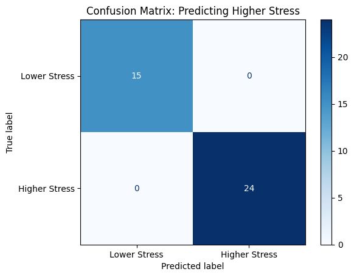

```python
conf_matrix= confusion_matrix(y_test, y_pred)
disp= ConfusionMatrixDisplay(confusion_matrix=conf_matrix, display_labels=['Lower Stress', 'Higher Stress'])
disp.plot(cmap='Blues', values_format='d')
plt.title('Confusion Matrix: Predicting Higher Stress')
plt.show()
```

The confusion matrix helps translate model quality into concrete outcomes. Instead of looking only at a single number such as accuracy, it shows which kinds of mistakes the model makes. In a mental-health context, that distinction matters: a model that frequently misses higher-stress individuals is much less useful than one that identifies them more reliably.

The confusion matrix shows perfect classification performance, with all lower-stress and higher-stress cases correctly predicted and no misclassifications.

```python
# Extract feature importances from the trained random forest.
rf_classifier= rf_pipeline.named_steps['classifier']
preprocessor= rf_pipeline.named_steps['preprocessor']

encoded_cat_features = []
if categorical_features:encoded_cat_features = list(preprocessor.named_transformers_['cat'].get_feature_names_out(categorical_features))

processed_feature_names = numeric_features + encoded_cat_features

feature_importance_df = (
    pd.DataFrame({
        'feature': processed_feature_names,
        'importance': rf_classifier.feature_importances_}).sort_values('importance', ascending=False))

feature_importance_df.head(10)
```

|  | feature | importance |
| --- | --- | --- |
| 4 | heart_rate | 0.238095 |
| 2 | quality_of_sleep | 0.223661 |
| 1 | sleep_duration | 0.143788 |
| 0 | age | 0.086093 |
| 3 | physical_activity_level | 0.060709 |
| 17 | occupation_Teacher | 0.056641 |
| 5 | daily_steps | 0.051354 |
| 7 | gender_Male | 0.037340 |
| 6 | gender_Female | 0.035615 |
| 8 | occupation_Accountant | 0.015031 |

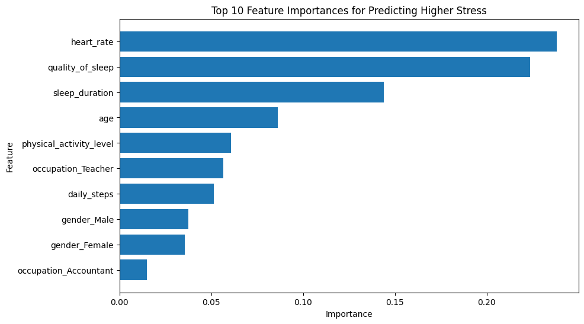

```python
plt.figure(figsize=(10, 6))
top_features = feature_importance_df.head(10).sort_values('importance')
plt.barh(top_features['feature'], top_features['importance'])
plt.title('Top 10 Feature Importances for Predicting Higher Stress')
plt.xlabel('Importance')
plt.ylabel('Feature')
plt.show()
```

Feature importance provides a more interpretable answer to the modeling question. Since the model performed extremely well on this dataset, the ranking of features helps identify which variables are most strongly associated with higher stress. In particular, heart_rate, quality_of_sleep, and sleep_duration emerge as the most important predictors, followed by age and physical_activity_level.

These results align with the overall goal of the analysis by showing that both physiological factors (heart rate) and lifestyle behaviors (sleep and activity) play a key role in predicting stress levels.

## 5. Conclusions and Recommendations

Feature importance analysis provides insight into which factors drive these predictions. The most influential variables include heart_rate, quality_of_sleep, and sleep_duration, followed by age and physical_activity_level. This indicates that both physiological signals and daily habits play a key role in determining stress levels.

Overall, the model suggests that higher stress is strongly associated with poorer sleep quality, shorter sleep duration, and elevated heart rate. From a practical perspective, this highlights the importance of improving sleep habits and maintaining a healthy lifestyle as potential ways to reduce stress.

Future work could involve validating the model on a larger or more diverse dataset to ensure that these patterns generalize beyond this sample.

```python
!jupyter nbconvert --to html Milestone1_StressProject.ipynb
```

[output not shown]

[output cut: 136 more lines]

[output not shown]